## Name:Saicharan Shetty

## ML2 PROJECT -PART2

# (1) LOGISTIC REGRESSION

```python
import numpy as np
import pandas as pd
import seaborn as sns
import matplotlib.pyplot as plt
%matplotlib inline
```

## Reading the data:

##### read the i/p data and rearrange the columns for easy analysis

```python
data = pd.read_csv('project', index_col=0)
```

```python
data
```

| PassengerId | Survived | Pclass | Age | SibSp | Parch | Fare | male | Q | S |
| --- | --- | --- | --- | --- | --- | --- | --- | --- | --- |
| 1 | 0 | 3 | 22.000000 | 1 | 0 | 7.25000 | 1 | 0 | 1 |
| 2 | 1 | 1 | 38.000000 | 1 | 0 | 14.45420 | 0 | 0 | 0 |
| 3 | 1 | 3 | 26.000000 | 0 | 0 | 7.92500 | 0 | 0 | 1 |
| 4 | 1 | 1 | 35.000000 | 1 | 0 | 28.85625 | 0 | 0 | 1 |
| 5 | 0 | 3 | 35.000000 | 0 | 0 | 8.05000 | 1 | 0 | 1 |
| 6 | 0 | 3 | 29.699118 | 0 | 0 | 8.45830 | 1 | 1 | 0 |
| 7 | 0 | 1 | 54.000000 | 0 | 0 | 28.85625 | 1 | 0 | 1 |
| 8 | 0 | 3 | 6.000000 | 3 | 1 | 21.07500 | 1 | 0 | 1 |
| 9 | 1 | 3 | 27.000000 | 0 | 2 | 11.13330 | 0 | 0 | 1 |
| 10 | 1 | 2 | 14.000000 | 1 | 0 | 30.07080 | 0 | 0 | 0 |
| 11 | 1 | 3 | 4.000000 | 1 | 1 | 16.70000 | 0 | 0 | 1 |
| 12 | 1 | 1 | 54.000000 | 0 | 0 | 26.55000 | 0 | 0 | 1 |
| 13 | 0 | 3 | 20.000000 | 0 | 0 | 8.05000 | 1 | 0 | 1 |
| 14 | 0 | 3 | 39.000000 | 1 | 5 | 31.27500 | 1 | 0 | 1 |
| 15 | 0 | 3 | 14.000000 | 0 | 0 | 7.85420 | 0 | 0 | 1 |
| 16 | 1 | 2 | 54.000000 | 0 | 0 | 16.00000 | 0 | 0 | 1 |
| 17 | 0 | 3 | 6.000000 | 4 | 1 | 29.12500 | 1 | 1 | 0 |
| 18 | 1 | 2 | 29.699118 | 0 | 0 | 13.00000 | 1 | 0 | 1 |
| 19 | 0 | 3 | 31.000000 | 1 | 0 | 18.00000 | 0 | 0 | 1 |
| 20 | 1 | 3 | 29.699118 | 0 | 0 | 7.22500 | 0 | 0 | 0 |
| 21 | 0 | 2 | 35.000000 | 0 | 0 | 26.00000 | 1 | 0 | 1 |
| 22 | 1 | 2 | 34.000000 | 0 | 0 | 13.00000 | 1 | 0 | 1 |
| 23 | 1 | 3 | 15.000000 | 0 | 0 | 8.02920 | 0 | 1 | 0 |
| 24 | 1 | 1 | 28.000000 | 0 | 0 | 35.50000 | 1 | 0 | 1 |
| 25 | 0 | 3 | 8.000000 | 3 | 1 | 21.07500 | 0 | 0 | 1 |
| 26 | 1 | 3 | 38.000000 | 1 | 5 | 31.38750 | 0 | 0 | 1 |
| 27 | 0 | 3 | 29.699118 | 0 | 0 | 7.22500 | 1 | 0 | 0 |
| 28 | 0 | 1 | 19.000000 | 3 | 2 | 14.45420 | 1 | 0 | 1 |
| 29 | 1 | 3 | 29.699118 | 0 | 0 | 7.87920 | 0 | 1 | 0 |
| 30 | 0 | 3 | 29.699118 | 0 | 0 | 7.89580 | 1 | 0 | 1 |
| ... | ... | ... | ... | ... | ... | ... | ... | ... | ... |
| 862 | 0 | 2 | 21.000000 | 1 | 0 | 11.50000 | 1 | 0 | 1 |
| 863 | 1 | 1 | 48.000000 | 0 | 0 | 25.92920 | 0 | 0 | 1 |
| 864 | 0 | 3 | 29.699118 | 8 | 2 | 14.45420 | 0 | 0 | 1 |
| 865 | 0 | 2 | 24.000000 | 0 | 0 | 13.00000 | 1 | 0 | 1 |
| 866 | 1 | 2 | 42.000000 | 0 | 0 | 13.00000 | 0 | 0 | 1 |
| 867 | 1 | 2 | 27.000000 | 1 | 0 | 13.85830 | 0 | 0 | 0 |
| 868 | 0 | 1 | 31.000000 | 0 | 0 | 28.85625 | 1 | 0 | 1 |
| 869 | 0 | 3 | 29.699118 | 0 | 0 | 9.50000 | 1 | 0 | 1 |
| 870 | 1 | 3 | 4.000000 | 1 | 1 | 11.13330 | 1 | 0 | 1 |
| 871 | 0 | 3 | 26.000000 | 0 | 0 | 7.89580 | 1 | 0 | 1 |
| 872 | 1 | 1 | 47.000000 | 1 | 1 | 28.85625 | 0 | 0 | 1 |
| 873 | 0 | 1 | 33.000000 | 0 | 0 | 5.00000 | 1 | 0 | 1 |
| 874 | 0 | 3 | 47.000000 | 0 | 0 | 9.00000 | 1 | 0 | 1 |
| 875 | 1 | 2 | 28.000000 | 1 | 0 | 24.00000 | 0 | 0 | 0 |
| 876 | 1 | 3 | 15.000000 | 0 | 0 | 7.22500 | 0 | 0 | 0 |
| 877 | 0 | 3 | 20.000000 | 0 | 0 | 9.84580 | 1 | 0 | 1 |
| 878 | 0 | 3 | 19.000000 | 0 | 0 | 7.89580 | 1 | 0 | 1 |
| 879 | 0 | 3 | 29.699118 | 0 | 0 | 7.89580 | 1 | 0 | 1 |
| 880 | 1 | 1 | 54.000000 | 0 | 1 | 14.45420 | 0 | 0 | 0 |
| 881 | 1 | 2 | 25.000000 | 0 | 1 | 26.00000 | 0 | 0 | 1 |
| 882 | 0 | 3 | 33.000000 | 0 | 0 | 7.89580 | 1 | 0 | 1 |
| 883 | 0 | 3 | 22.000000 | 0 | 0 | 10.51670 | 0 | 0 | 1 |
| 884 | 0 | 2 | 28.000000 | 0 | 0 | 10.50000 | 1 | 0 | 1 |
| 885 | 0 | 3 | 25.000000 | 0 | 0 | 7.05000 | 1 | 0 | 1 |
| 886 | 0 | 3 | 39.000000 | 0 | 5 | 29.12500 | 0 | 1 | 0 |
| 887 | 0 | 2 | 27.000000 | 0 | 0 | 13.00000 | 1 | 0 | 1 |
| 888 | 1 | 1 | 19.000000 | 0 | 0 | 30.00000 | 0 | 0 | 1 |
| 889 | 0 | 3 | 29.699118 | 1 | 2 | 23.45000 | 0 | 0 | 1 |
| 890 | 1 | 1 | 26.000000 | 0 | 0 | 30.00000 | 1 | 0 | 0 |
| 891 | 0 | 3 | 32.000000 | 0 | 0 | 7.75000 | 1 | 1 | 0 |

891 rows × 9 columns

```python
data=pd.DataFrame(data,columns=[ 'Pclass', 'Age', 'SibSp', 'Parch', 'Fare', 'male', 'Q',
       'S','Survived',])
data
```

| PassengerId | Pclass | Age | SibSp | Parch | Fare | male | Q | S | Survived |
| --- | --- | --- | --- | --- | --- | --- | --- | --- | --- |
| 1 | 3 | 22.000000 | 1 | 0 | 7.25000 | 1 | 0 | 1 | 0 |
| 2 | 1 | 38.000000 | 1 | 0 | 14.45420 | 0 | 0 | 0 | 1 |
| 3 | 3 | 26.000000 | 0 | 0 | 7.92500 | 0 | 0 | 1 | 1 |
| 4 | 1 | 35.000000 | 1 | 0 | 28.85625 | 0 | 0 | 1 | 1 |
| 5 | 3 | 35.000000 | 0 | 0 | 8.05000 | 1 | 0 | 1 | 0 |
| 6 | 3 | 29.699118 | 0 | 0 | 8.45830 | 1 | 1 | 0 | 0 |
| 7 | 1 | 54.000000 | 0 | 0 | 28.85625 | 1 | 0 | 1 | 0 |
| 8 | 3 | 6.000000 | 3 | 1 | 21.07500 | 1 | 0 | 1 | 0 |
| 9 | 3 | 27.000000 | 0 | 2 | 11.13330 | 0 | 0 | 1 | 1 |
| 10 | 2 | 14.000000 | 1 | 0 | 30.07080 | 0 | 0 | 0 | 1 |
| 11 | 3 | 4.000000 | 1 | 1 | 16.70000 | 0 | 0 | 1 | 1 |
| 12 | 1 | 54.000000 | 0 | 0 | 26.55000 | 0 | 0 | 1 | 1 |
| 13 | 3 | 20.000000 | 0 | 0 | 8.05000 | 1 | 0 | 1 | 0 |
| 14 | 3 | 39.000000 | 1 | 5 | 31.27500 | 1 | 0 | 1 | 0 |
| 15 | 3 | 14.000000 | 0 | 0 | 7.85420 | 0 | 0 | 1 | 0 |
| 16 | 2 | 54.000000 | 0 | 0 | 16.00000 | 0 | 0 | 1 | 1 |
| 17 | 3 | 6.000000 | 4 | 1 | 29.12500 | 1 | 1 | 0 | 0 |
| 18 | 2 | 29.699118 | 0 | 0 | 13.00000 | 1 | 0 | 1 | 1 |
| 19 | 3 | 31.000000 | 1 | 0 | 18.00000 | 0 | 0 | 1 | 0 |
| 20 | 3 | 29.699118 | 0 | 0 | 7.22500 | 0 | 0 | 0 | 1 |
| 21 | 2 | 35.000000 | 0 | 0 | 26.00000 | 1 | 0 | 1 | 0 |
| 22 | 2 | 34.000000 | 0 | 0 | 13.00000 | 1 | 0 | 1 | 1 |
| 23 | 3 | 15.000000 | 0 | 0 | 8.02920 | 0 | 1 | 0 | 1 |
| 24 | 1 | 28.000000 | 0 | 0 | 35.50000 | 1 | 0 | 1 | 1 |
| 25 | 3 | 8.000000 | 3 | 1 | 21.07500 | 0 | 0 | 1 | 0 |
| 26 | 3 | 38.000000 | 1 | 5 | 31.38750 | 0 | 0 | 1 | 1 |
| 27 | 3 | 29.699118 | 0 | 0 | 7.22500 | 1 | 0 | 0 | 0 |
| 28 | 1 | 19.000000 | 3 | 2 | 14.45420 | 1 | 0 | 1 | 0 |
| 29 | 3 | 29.699118 | 0 | 0 | 7.87920 | 0 | 1 | 0 | 1 |
| 30 | 3 | 29.699118 | 0 | 0 | 7.89580 | 1 | 0 | 1 | 0 |
| ... | ... | ... | ... | ... | ... | ... | ... | ... | ... |
| 862 | 2 | 21.000000 | 1 | 0 | 11.50000 | 1 | 0 | 1 | 0 |
| 863 | 1 | 48.000000 | 0 | 0 | 25.92920 | 0 | 0 | 1 | 1 |
| 864 | 3 | 29.699118 | 8 | 2 | 14.45420 | 0 | 0 | 1 | 0 |
| 865 | 2 | 24.000000 | 0 | 0 | 13.00000 | 1 | 0 | 1 | 0 |
| 866 | 2 | 42.000000 | 0 | 0 | 13.00000 | 0 | 0 | 1 | 1 |
| 867 | 2 | 27.000000 | 1 | 0 | 13.85830 | 0 | 0 | 0 | 1 |
| 868 | 1 | 31.000000 | 0 | 0 | 28.85625 | 1 | 0 | 1 | 0 |
| 869 | 3 | 29.699118 | 0 | 0 | 9.50000 | 1 | 0 | 1 | 0 |
| 870 | 3 | 4.000000 | 1 | 1 | 11.13330 | 1 | 0 | 1 | 1 |
| 871 | 3 | 26.000000 | 0 | 0 | 7.89580 | 1 | 0 | 1 | 0 |
| 872 | 1 | 47.000000 | 1 | 1 | 28.85625 | 0 | 0 | 1 | 1 |
| 873 | 1 | 33.000000 | 0 | 0 | 5.00000 | 1 | 0 | 1 | 0 |
| 874 | 3 | 47.000000 | 0 | 0 | 9.00000 | 1 | 0 | 1 | 0 |
| 875 | 2 | 28.000000 | 1 | 0 | 24.00000 | 0 | 0 | 0 | 1 |
| 876 | 3 | 15.000000 | 0 | 0 | 7.22500 | 0 | 0 | 0 | 1 |
| 877 | 3 | 20.000000 | 0 | 0 | 9.84580 | 1 | 0 | 1 | 0 |
| 878 | 3 | 19.000000 | 0 | 0 | 7.89580 | 1 | 0 | 1 | 0 |
| 879 | 3 | 29.699118 | 0 | 0 | 7.89580 | 1 | 0 | 1 | 0 |
| 880 | 1 | 54.000000 | 0 | 1 | 14.45420 | 0 | 0 | 0 | 1 |
| 881 | 2 | 25.000000 | 0 | 1 | 26.00000 | 0 | 0 | 1 | 1 |
| 882 | 3 | 33.000000 | 0 | 0 | 7.89580 | 1 | 0 | 1 | 0 |
| 883 | 3 | 22.000000 | 0 | 0 | 10.51670 | 0 | 0 | 1 | 0 |
| 884 | 2 | 28.000000 | 0 | 0 | 10.50000 | 1 | 0 | 1 | 0 |
| 885 | 3 | 25.000000 | 0 | 0 | 7.05000 | 1 | 0 | 1 | 0 |
| 886 | 3 | 39.000000 | 0 | 5 | 29.12500 | 0 | 1 | 0 | 0 |
| 887 | 2 | 27.000000 | 0 | 0 | 13.00000 | 1 | 0 | 1 | 0 |
| 888 | 1 | 19.000000 | 0 | 0 | 30.00000 | 0 | 0 | 1 | 1 |
| 889 | 3 | 29.699118 | 1 | 2 | 23.45000 | 0 | 0 | 1 | 0 |
| 890 | 1 | 26.000000 | 0 | 0 | 30.00000 | 1 | 0 | 0 | 1 |
| 891 | 3 | 32.000000 | 0 | 0 | 7.75000 | 1 | 1 | 0 | 0 |

891 rows × 9 columns

## Defining the dependent(y) and independent(x) variables:

```python
x=data.iloc[:,:-1].values
print(x.shape)
x
```

```
(891, 8)
```

```
array([[ 3.        , 22.        ,  1.        , ...,  1.        ,
         0.        ,  1.        ],
       [ 1.        , 38.        ,  1.        , ...,  0.        ,
         0.        ,  0.        ],
       [ 3.        , 26.        ,  0.        , ...,  0.        ,
         0.        ,  1.        ],
       ...,
       [ 3.        , 29.69911765,  1.        , ...,  0.        ,
         0.        ,  1.        ],
       [ 1.        , 26.        ,  0.        , ...,  1.        ,
         0.        ,  0.        ],
       [ 3.        , 32.        ,  0.        , ...,  1.        ,
         1.        ,  0.        ]])
```

```python
y=data.iloc[:,-1].values
print(y.shape)
y
```

```
(891,)
```

```
array([0, 1, 1, 1, 0, 0, 0, 0, 1, 1, 1, 1, 0, 0, 0, 1, 0, 1, 0, 1, 0, 1,
       1, 1, 0, 1, 0, 0, 1, 0, 0, 1, 1, 0, 0, 0, 1, 0, 0, 1, 0, 0, 0, 1,
       1, 0, 0, 1, 0, 0, 0, 0, 1, 1, 0, 1, 1, 0, 1, 0, 0, 1, 0, 0, 0, 1,
       1, 0, 1, 0, 0, 0, 0, 0, 1, 0, 0, 0, 1, 1, 0, 1, 1, 0, 1, 1, 0, 0,
       1, 0, 0, 0, 0, 0, 0, 0, 0, 1, 1, 0, 0, 0, 0, 0, 0, 0, 1, 1, 0, 1,
       0, 0, 0, 0, 0, 0, 0, 0, 0, 0, 0, 0, 0, 1, 0, 1, 0, 1, 1, 0, 0, 0,
       0, 1, 0, 0, 1, 0, 0, 0, 0, 1, 1, 0, 0, 0, 1, 0, 0, 0, 0, 1, 0, 0,
       0, 0, 1, 0, 0, 0, 0, 1, 0, 0, 0, 1, 1, 0, 0, 0, 0, 0, 1, 0, 0, 0,
       0, 0, 0, 0, 0, 0, 0, 1, 1, 0, 1, 1, 0, 0, 1, 0, 1, 1, 1, 1, 0, 0,
       1, 0, 0, 0, 0, 0, 1, 0, 0, 1, 1, 1, 0, 1, 0, 0, 0, 1, 1, 0, 1, 0,
       1, 0, 0, 0, 1, 0, 1, 0, 0, 0, 1, 0, 0, 1, 0, 0, 0, 1, 0, 0, 0, 1,
       0, 0, 0, 0, 0, 1, 1, 0, 0, 0, 0, 0, 0, 1, 1, 1, 1, 1, 0, 1, 0, 0,
       0, 0, 0, 1, 1, 1, 0, 1, 1, 0, 1, 1, 0, 0, 0, 1, 0, 0, 0, 1, 0, 0,
       1, 0, 1, 1, 1, 1, 0, 0, 0, 0, 0, 0, 1, 1, 1, 1, 0, 1, 0, 1, 1, 1,
       0, 1, 1, 1, 0, 0, 0, 1, 1, 0, 1, 1, 0, 0, 1, 1, 0, 1, 0, 1, 1, 1,
```

[output cut: 26 more lines]

## Splitting the data into train and test dataset:

```python
from sklearn.model_selection import train_test_split
##splitting into train and test
xtrain,xtest,ytrain,ytest=train_test_split(x,y,test_size=0.2,random_state=6)
```

```python
pd.DataFrame([xtrain.shape , xtest.shape  , ytrain.shape  ,  ytest.shape],index=['xtrain','xtest','ytrain','ytest'],columns=['row','columns'])
```

|  | row | columns |
| --- | --- | --- |
| xtrain | 712 | 8.0 |
| xtest | 179 | 8.0 |
| ytrain | 712 | NaN |
| ytest | 179 | NaN |

## Scaling the independent variables

```python
from sklearn.preprocessing import StandardScaler
scaler=StandardScaler()
xtrain=scaler.fit_transform(xtrain)
xtest=scaler.transform(xtest)
```

## Building the model:

```python
from sklearn.linear_model import LogisticRegression
LR=LogisticRegression()
#fitting the model on train data set
LR.fit(xtrain,ytrain)
```

```
LogisticRegression(C=1.0, class_weight=None, dual=False, fit_intercept=True,
          intercept_scaling=1, max_iter=100, multi_class='warn',
          n_jobs=None, penalty='l2', random_state=None, solver='warn',
          tol=0.0001, verbose=0, warm_start=False)
```

```python
ypred=LR.predict(xtest)
ypred
```

```
array([1, 0, 0, 1, 0, 0, 0, 0, 0, 0, 0, 1, 0, 0, 1, 0, 0, 0, 1, 1, 0, 0,
       1, 0, 0, 0, 0, 0, 0, 1, 1, 0, 0, 0, 1, 0, 0, 0, 0, 1, 1, 0, 0, 0,
       0, 0, 0, 0, 1, 0, 0, 0, 0, 0, 0, 0, 1, 0, 0, 1, 0, 0, 0, 0, 1, 1,
       1, 0, 0, 0, 1, 0, 0, 0, 0, 1, 0, 0, 1, 0, 0, 1, 1, 0, 0, 1, 0, 0,
       1, 0, 1, 1, 0, 0, 0, 0, 0, 1, 0, 1, 0, 1, 0, 1, 0, 0, 0, 1, 1, 1,
       0, 0, 0, 1, 0, 0, 1, 0, 0, 1, 1, 0, 0, 0, 0, 1, 1, 0, 0, 0, 0, 1,
       1, 1, 0, 1, 1, 0, 0, 0, 0, 0, 1, 0, 0, 1, 0, 1, 0, 0, 1, 1, 0, 1,
       0, 0, 0, 0, 1, 0, 1, 1, 0, 0, 1, 0, 0, 0, 0, 1, 0, 0, 0, 0, 1, 0,
       0, 1, 0], dtype=int64)
```

```python
ytest
```

```
array([1, 0, 0, 1, 1, 0, 0, 0, 0, 0, 0, 1, 1, 0, 1, 1, 0, 0, 1, 1, 0, 0,
       1, 0, 1, 0, 0, 0, 0, 1, 1, 0, 0, 0, 0, 0, 1, 0, 0, 0, 0, 0, 0, 0,
       0, 1, 1, 1, 1, 0, 1, 1, 0, 0, 0, 0, 1, 0, 0, 0, 0, 0, 0, 0, 1, 1,
       1, 0, 0, 0, 0, 0, 0, 0, 0, 1, 0, 1, 1, 0, 0, 1, 1, 0, 0, 1, 1, 0,
       1, 1, 1, 1, 0, 0, 0, 0, 0, 1, 0, 0, 0, 0, 0, 1, 0, 0, 0, 1, 0, 1,
       0, 0, 0, 1, 0, 0, 1, 0, 0, 1, 1, 0, 0, 0, 0, 1, 1, 1, 0, 1, 0, 1,
       1, 1, 0, 0, 1, 0, 0, 0, 0, 0, 1, 0, 0, 1, 0, 1, 0, 0, 1, 1, 0, 1,
       0, 0, 1, 0, 1, 0, 1, 0, 0, 0, 1, 0, 0, 1, 0, 1, 0, 0, 0, 0, 1, 0,
       0, 1, 1], dtype=int64)
```

## Model evaluation using confusion matrix:

```python
from sklearn.metrics import confusion_matrix
cmat=confusion_matrix(ytest,ypred)
print(cmat)
TP=cmat[1,1]
TN=cmat[0,0]
FP=cmat[0,1]
FN=cmat[1,0]
pd.DataFrame([TP,TN,FP,FN],index=['TP','TN','FP','FN'])
```

```
[[103  10]
 [ 18  48]]
```

|  | 0 |
| --- | --- |
| TP | 48 |
| TN | 103 |
| FP | 10 |
| FN | 18 |

### confusion matrix parameters:

#### 1.clasification accuracy:

```python
from sklearn import metrics as met
accuracy=met.accuracy_score(ytest,ypred)
print("classification accuracy:",accuracy*100)
```

```
classification accuracy: 84.35754189944134
```

#### 2.classification error:

```python
print("classification error is :",100*(1-accuracy))
```

```
classification error is : 15.642458100558654
```

#### 3. a)TPR( true positive rate) b)TNR(true negetive rate)

#### c) FPR(false positive rate) d) FNR(false negetive rate)

```python
TPR=100*met.recall_score(ytest,ypred)
TNR=100*TN/(TN+FP)
FPR=100-TNR
FNR=100-TPR

pd.DataFrame([TPR,TNR,FPR,FNR],index=['TPR/SENSITIVITY','TNR/SPECIFICITY','FPR','FNR'])
```

|  | 0 |
| --- | --- |
| TPR/SENSITIVITY | 72.727273 |
| TNR/SPECIFICITY | 91.150442 |
| FPR | 8.849558 |
| FNR | 27.272727 |

```python
from sklearn.metrics import precision_score,f1_score,roc_auc_score
precision=precision_score(ytest,ypred)
f1=f1_score(ytest,ypred)
roc_auc=roc_auc_score(ytest,ypred)
pd.DataFrame([precision,f1,roc_auc],index=['precision','F1_score','roc_auc'])
```

|  | 0 |
| --- | --- |
| precision | 0.827586 |
| F1_score | 0.774194 |
| roc_auc | 0.819389 |

#### The accuracy of this model is 84.35% for the given test split of 20% and random state=6

# .------------------------.------------------.--------------.--------------.-----------.------------------------

# .

# .

# .

# .

# .

# .

# .

# .

# .

# .

# .

# (2) KNN Classifier:

## splitting the data into train and test split:

```python
from sklearn.model_selection import train_test_split
##splitting into train and test
xtrain,xtest,ytrain,ytest=train_test_split(x,y,test_size=0.33,random_state=5)
```

```python
pd.DataFrame([xtrain.shape , xtest.shape  , ytrain.shape  ,  ytest.shape],index=['xtrain','xtest','ytrain','ytest'],columns=['row','columns'])
```

|  | row | columns |
| --- | --- | --- |
| xtrain | 596 | 8.0 |
| xtest | 295 | 8.0 |
| ytrain | 596 | NaN |
| ytest | 295 | NaN |

## Scaling the independent variables

```python
from sklearn.preprocessing import StandardScaler
scaler=StandardScaler()
xtrain=scaler.fit_transform(xtrain)
xtest=scaler.transform(xtest)
```

## Building the model:

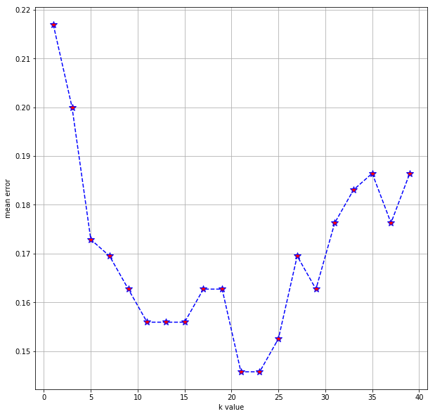

```python
#Choose for best value of K by calculating the mean error for each value of K
error=[]
from sklearn.neighbors import KNeighborsClassifier
for i in range(1,40,2):
    knn=KNeighborsClassifier(n_neighbors=i)
    knn.fit(xtrain,ytrain)
    yp=knn.predict(xtest)
    error.append(np.mean(yp!=ytest))
plt.figure(figsize=(10,10))
plt.plot(range(1,40,2),error,color='b',linestyle='dashed',marker='*',markerfacecolor='r',markersize='10')
plt.xlabel('k value')
plt.ylabel('mean error')
plt.grid(True)
```

```python
from sklearn.neighbors import KNeighborsClassifier
knn=KNeighborsClassifier(n_neighbors=21)
knn.fit(xtrain,ytrain)
```

```
KNeighborsClassifier(algorithm='auto', leaf_size=30, metric='minkowski',
           metric_params=None, n_jobs=None, n_neighbors=21, p=2,
           weights='uniform')
```

```python
ypred=knn.predict(xtest)
ypred
```

```
array([0, 0, 0, 0, 0, 0, 1, 0, 1, 0, 0, 0, 0, 1, 0, 1, 0, 1, 0, 0, 0, 1,
       1, 1, 0, 0, 0, 0, 0, 0, 0, 1, 1, 0, 1, 1, 0, 0, 0, 0, 0, 1, 0, 0,
       0, 0, 1, 1, 0, 0, 0, 1, 1, 0, 0, 0, 0, 0, 0, 1, 0, 0, 0, 0, 1, 0,
       0, 0, 0, 0, 1, 0, 1, 0, 0, 0, 0, 1, 1, 1, 0, 0, 0, 0, 1, 1, 0, 1,
       0, 0, 0, 0, 1, 0, 1, 0, 1, 0, 0, 0, 0, 1, 0, 0, 1, 1, 0, 0, 0, 1,
       0, 0, 0, 0, 1, 0, 1, 1, 1, 0, 1, 0, 0, 1, 0, 1, 0, 0, 0, 0, 0, 0,
       0, 0, 1, 0, 0, 0, 0, 0, 0, 0, 0, 1, 0, 1, 0, 1, 0, 1, 1, 0, 0, 0,
       0, 1, 1, 0, 0, 0, 0, 0, 0, 0, 1, 0, 1, 0, 0, 0, 1, 0, 1, 1, 0, 0,
       0, 1, 0, 1, 1, 1, 0, 0, 1, 0, 1, 0, 0, 0, 0, 0, 0, 0, 0, 0, 0, 1,
       0, 0, 1, 0, 0, 0, 0, 1, 0, 0, 0, 0, 0, 0, 1, 0, 0, 0, 1, 0, 0, 0,
       0, 0, 1, 0, 1, 1, 0, 1, 1, 0, 1, 0, 0, 0, 0, 0, 0, 0, 0, 1, 0, 1,
       0, 1, 0, 0, 0, 1, 0, 0, 0, 0, 0, 0, 0, 0, 0, 0, 1, 0, 0, 1, 0, 0,
       0, 0, 0, 1, 0, 1, 0, 0, 0, 0, 0, 1, 0, 0, 0, 0, 1, 0, 0, 1, 0, 0,
       0, 0, 0, 0, 0, 0, 0, 1, 0], dtype=int64)
```

```python
ytest
```

```
array([0, 0, 0, 1, 0, 0, 1, 1, 1, 0, 0, 0, 1, 1, 0, 1, 1, 0, 0, 0, 0, 1,
       1, 1, 0, 0, 1, 1, 0, 0, 0, 1, 1, 1, 1, 1, 0, 1, 0, 0, 0, 1, 1, 1,
       0, 0, 1, 1, 0, 0, 0, 0, 1, 0, 1, 0, 0, 0, 0, 1, 0, 0, 0, 0, 1, 0,
       0, 0, 1, 0, 1, 0, 0, 0, 0, 0, 0, 0, 1, 1, 0, 0, 0, 0, 1, 1, 0, 1,
       0, 1, 0, 0, 1, 0, 1, 0, 1, 0, 0, 0, 1, 0, 0, 0, 1, 1, 0, 0, 0, 1,
       0, 0, 0, 1, 1, 1, 1, 1, 1, 1, 1, 1, 0, 1, 0, 1, 1, 0, 0, 0, 0, 0,
       0, 0, 1, 0, 0, 0, 0, 0, 0, 0, 0, 0, 0, 1, 0, 1, 0, 1, 1, 0, 0, 0,
       0, 0, 1, 0, 0, 0, 0, 1, 0, 0, 1, 0, 1, 0, 0, 0, 1, 0, 1, 1, 0, 0,
       0, 1, 0, 1, 1, 1, 0, 0, 1, 0, 1, 0, 1, 0, 0, 0, 0, 0, 0, 0, 0, 1,
       0, 0, 1, 0, 0, 0, 0, 1, 0, 0, 0, 0, 0, 0, 1, 1, 0, 0, 1, 0, 0, 0,
       1, 1, 1, 1, 1, 1, 1, 1, 1, 0, 1, 0, 0, 0, 0, 0, 0, 0, 1, 1, 0, 1,
       0, 1, 0, 1, 1, 1, 0, 0, 1, 1, 0, 0, 0, 0, 0, 0, 0, 0, 0, 1, 0, 0,
       0, 0, 0, 1, 0, 1, 1, 0, 0, 0, 0, 1, 0, 1, 0, 0, 0, 0, 0, 1, 0, 0,
       1, 0, 0, 0, 0, 0, 0, 1, 0], dtype=int64)
```

## Model evaluation using confusion matrix:

```python
from sklearn.metrics import confusion_matrix
cmat=confusion_matrix(ytest,ypred)
print(cmat)
TP=cmat[1,1]
TN=cmat[0,0]
FP=cmat[0,1]
FN=cmat[1,0]
pd.DataFrame([TP,TN,FP,FN],index=['TP','TN','FP','FN'])
```

```
[[178   9]
 [ 34  74]]
```

|  | 0 |
| --- | --- |
| TP | 74 |
| TN | 178 |
| FP | 9 |
| FN | 34 |

### confusion matrix parameters:

#### 1.clasification accuracy:

```python
from sklearn import metrics as met
accuracy=met.accuracy_score(ytest,ypred)
print("classification accuracy:",accuracy*100)
```

```
classification accuracy: 85.42372881355932
```

##### 2.classification error:

```python
print("classification error is :",100*(1-accuracy))
```

```
classification error is : 14.576271186440682
```

#### 3. a)TPR( true positive rate) b)TNR(true negetive rate)

#### c) FPR(false positive rate) d) FNR(false negetive rate)

```python
TPR=100*met.recall_score(ytest,ypred)
TNR=100*TN/(TN+FP)
FPR=100-TNR
FNR=100-TPR

pd.DataFrame([TPR,TNR,FPR,FNR],index=['TPR/SENSITIVITY','TNR/SPECIFICITY','FPR','FNR'])
```

|  | 0 |
| --- | --- |
| TPR/SENSITIVITY | 68.518519 |
| TNR/SPECIFICITY | 95.187166 |
| FPR | 4.812834 |
| FNR | 31.481481 |

```python
from sklearn.metrics import precision_score,f1_score,roc_auc_score
precision=precision_score(ytest,ypred)
f1=f1_score(ytest,ypred)
roc_auc=roc_auc_score(ytest,ypred)
pd.DataFrame([precision,f1,roc_auc],index=['precision','F1_score','roc_auc'])
```

|  | 0 |
| --- | --- |
| precision | 0.891566 |
| F1_score | 0.774869 |
| roc_auc | 0.818528 |

#### The accuracy of this model is 85.42% for the given test split of 33% and random state=5

```
22 - 0.8585365853658536
```

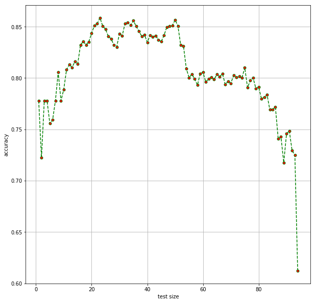

```python
# plot of accuracy for various values of test size
from sklearn.model_selection import train_test_split
from sklearn.preprocessing import StandardScaler
from sklearn import metrics as met
from sklearn.neighbors import KNeighborsClassifier
acc=[]
for i in range(1,95,1):
    xtrain,xtest,ytrain,ytest=train_test_split(x,y,test_size=i/100,random_state=5)
    scaler=StandardScaler()
    xtrain=scaler.fit_transform(xtrain)
    xtest=scaler.transform(xtest)
    knn=KNeighborsClassifier(n_neighbors=21)
    knn.fit(xtrain,ytrain)
    ypred=knn.predict(xtest)
    accuracy=met.accuracy_score(ytest,ypred)
    acc.append(accuracy)
plt.figure(figsize=(10,10))
plt.plot(range(1,95,1),acc,color='g',linestyle='dashed',marker='.',markerfacecolor='r',markersize='10')
plt.xlabel('test size')
plt.ylabel('accuracy')
plt.grid(True)
print(acc.index(max(acc)),'-',max(acc))
```

# .------------------------.------------------.--------------.--------------.-----------.------------------------

# .

# .

# .

# .

# .

# .

# .

# .

# .

# .

# .

# (3) DECISION TREE Classifier:

## splitting the data into train and test split:

```python
from sklearn.model_selection import train_test_split
#splitting into train and test
xtrain,xtest,ytrain,ytest=train_test_split(x,y,test_size=0.33,random_state=5)
```

```python
pd.DataFrame([xtrain.shape , xtest.shape  , ytrain.shape  ,  ytest.shape],index=['xtrain','xtest','ytrain','ytest'],columns=['row','columns'])
```

|  | row | columns |
| --- | --- | --- |
| xtrain | 596 | 8.0 |
| xtest | 295 | 8.0 |
| ytrain | 596 | NaN |
| ytest | 295 | NaN |

## Scaling the independent variables

```python
from sklearn.preprocessing import StandardScaler
scaler=StandardScaler()
xtrain=scaler.fit_transform(xtrain)
xtest=scaler.transform(xtest)
```

## Building the model:

```python
from sklearn.tree import DecisionTreeClassifier
dt=DecisionTreeClassifier()
dt.fit(xtrain,ytrain)
ypred=dt.predict(xtest)
```

```python
ypred
```

```
array([0, 0, 0, 0, 1, 0, 1, 0, 1, 0, 0, 0, 0, 1, 0, 1, 0, 0, 0, 0, 0, 1,
       1, 0, 0, 0, 0, 1, 0, 0, 0, 1, 1, 0, 1, 1, 0, 0, 0, 0, 0, 1, 0, 0,
       0, 0, 1, 1, 1, 0, 0, 1, 1, 0, 0, 0, 1, 0, 0, 1, 0, 1, 0, 0, 1, 0,
       0, 0, 1, 0, 1, 0, 1, 0, 1, 0, 0, 0, 1, 1, 0, 0, 0, 0, 1, 1, 0, 1,
       0, 0, 1, 0, 1, 0, 1, 0, 1, 0, 0, 0, 1, 1, 0, 0, 1, 1, 0, 0, 0, 0,
       0, 0, 0, 0, 1, 1, 1, 0, 1, 0, 0, 0, 0, 1, 0, 1, 0, 0, 0, 1, 0, 0,
       0, 0, 1, 0, 0, 0, 0, 0, 0, 0, 0, 0, 1, 1, 0, 1, 0, 1, 1, 0, 0, 0,
       0, 1, 1, 0, 0, 0, 0, 1, 0, 0, 1, 0, 1, 0, 0, 0, 1, 0, 0, 1, 0, 1,
       0, 1, 0, 1, 1, 1, 0, 0, 1, 0, 1, 0, 0, 0, 1, 1, 0, 0, 0, 0, 0, 1,
       0, 0, 1, 0, 0, 0, 1, 1, 0, 0, 0, 0, 0, 0, 1, 0, 0, 0, 0, 0, 0, 0,
       0, 0, 1, 0, 1, 1, 0, 0, 0, 0, 1, 0, 0, 0, 0, 0, 0, 0, 1, 1, 0, 1,
       0, 0, 0, 0, 0, 1, 1, 0, 0, 0, 0, 1, 0, 0, 0, 1, 1, 0, 0, 1, 0, 0,
       0, 0, 0, 0, 0, 1, 0, 0, 0, 0, 0, 1, 0, 1, 0, 0, 1, 0, 0, 1, 0, 0,
       0, 0, 0, 0, 0, 0, 0, 1, 0], dtype=int64)
```

```python
ytest
```

```
array([0, 0, 0, 1, 0, 0, 1, 1, 1, 0, 0, 0, 1, 1, 0, 1, 1, 0, 0, 0, 0, 1,
       1, 1, 0, 0, 1, 1, 0, 0, 0, 1, 1, 1, 1, 1, 0, 1, 0, 0, 0, 1, 1, 1,
       0, 0, 1, 1, 0, 0, 0, 0, 1, 0, 1, 0, 0, 0, 0, 1, 0, 0, 0, 0, 1, 0,
       0, 0, 1, 0, 1, 0, 0, 0, 0, 0, 0, 0, 1, 1, 0, 0, 0, 0, 1, 1, 0, 1,
       0, 1, 0, 0, 1, 0, 1, 0, 1, 0, 0, 0, 1, 0, 0, 0, 1, 1, 0, 0, 0, 1,
       0, 0, 0, 1, 1, 1, 1, 1, 1, 1, 1, 1, 0, 1, 0, 1, 1, 0, 0, 0, 0, 0,
       0, 0, 1, 0, 0, 0, 0, 0, 0, 0, 0, 0, 0, 1, 0, 1, 0, 1, 1, 0, 0, 0,
       0, 0, 1, 0, 0, 0, 0, 1, 0, 0, 1, 0, 1, 0, 0, 0, 1, 0, 1, 1, 0, 0,
       0, 1, 0, 1, 1, 1, 0, 0, 1, 0, 1, 0, 1, 0, 0, 0, 0, 0, 0, 0, 0, 1,
       0, 0, 1, 0, 0, 0, 0, 1, 0, 0, 0, 0, 0, 0, 1, 1, 0, 0, 1, 0, 0, 0,
       1, 1, 1, 1, 1, 1, 1, 1, 1, 0, 1, 0, 0, 0, 0, 0, 0, 0, 1, 1, 0, 1,
       0, 1, 0, 1, 1, 1, 0, 0, 1, 1, 0, 0, 0, 0, 0, 0, 0, 0, 0, 1, 0, 0,
       0, 0, 0, 1, 0, 1, 1, 0, 0, 0, 0, 1, 0, 1, 0, 0, 0, 0, 0, 1, 0, 0,
       1, 0, 0, 0, 0, 0, 0, 1, 0], dtype=int64)
```

[figure not shown]

```python
from sklearn.externals.six import StringIO
from IPython.display import Image
from sklearn.tree import export_graphviz
import pydotplus
dot_data = StringIO()
export_graphviz(dt, out_file=dot_data,filled=True, rounded=True,special_characters=True)
graph = pydotplus.graph_from_dot_data(dot_data.getvalue())
Image(graph.create_png(), width=12000, height=12000)
```

## Model evaluation using confusion matrix:

```python
from sklearn.metrics import confusion_matrix
cmat=confusion_matrix(ytest,ypred)
print(cmat)
TP=cmat[1,1]
TN=cmat[0,0]
FP=cmat[0,1]
FN=cmat[1,0]
pd.DataFrame([TP,TN,FP,FN],index=['TP','TN','FP','FN'])
```

```
[[166  21]
 [ 37  71]]
```

|  | 0 |
| --- | --- |
| TP | 71 |
| TN | 166 |
| FP | 21 |
| FN | 37 |

### confusion matrix parameters:

#### 1.clasification accuracy:

```python
from sklearn import metrics as met
accuracy=met.accuracy_score(ytest,ypred)
print("classification accuracy:",accuracy*100)
```

```
classification accuracy: 80.33898305084746
```

##### 2.classification error:

```python
print("classification error is :",100*(1-accuracy))
```

```
classification error is : 19.661016949152543
```

#### 3. a)TPR( true positive rate) b)TNR(true negetive rate)

#### c) FPR(false positive rate) d) FNR(false negetive rate)

```python
TPR=100*met.recall_score(ytest,ypred)
TNR=100*TN/(TN+FP)
FPR=100-TNR
FNR=100-TPR

pd.DataFrame([TPR,TNR,FPR,FNR],index=['TPR/SENSITIVITY','TNR/SPECIFICITY','FPR','FNR'])
```

|  | 0 |
| --- | --- |
| TPR/SENSITIVITY | 65.740741 |
| TNR/SPECIFICITY | 88.770053 |
| FPR | 11.229947 |
| FNR | 34.259259 |

```python
from sklearn.metrics import precision_score,f1_score,roc_auc_score
precision=precision_score(ytest,ypred)
f1=f1_score(ytest,ypred)
roc_auc=roc_auc_score(ytest,ypred)
pd.DataFrame([precision,f1,roc_auc],index=['precision','F1_score','roc_auc'])
```

|  | 0 |
| --- | --- |
| precision | 0.771739 |
| F1_score | 0.710000 |
| roc_auc | 0.772554 |

#### The accuracy of this model is 80.33% for the given test split of 33% and random state=5

```
3 - 0.8333333333333334
```

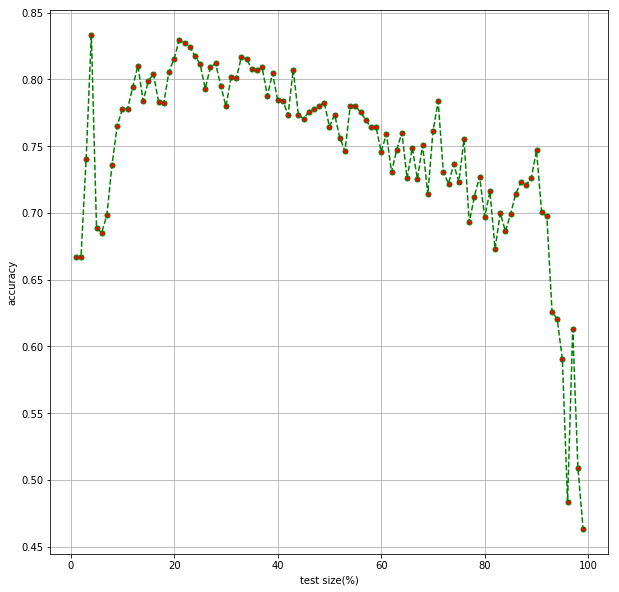

```python
# finding the best values of accuracy by varying test size
from sklearn.model_selection import train_test_split
from sklearn.preprocessing import StandardScaler
from sklearn import metrics as met
from sklearn.tree import DecisionTreeClassifier
acc=[]
for i in range(1,100,1):
    xtrain,xtest,ytrain,ytest=train_test_split(x,y,test_size=i/100,random_state=5)
    scaler=StandardScaler()
    xtrain=scaler.fit_transform(xtrain)
    xtest=scaler.transform(xtest)
    dt=DecisionTreeClassifier()
    dt.fit(xtrain,ytrain)
    ypred=dt.predict(xtest)
    accuracy=met.accuracy_score(ytest,ypred)
    acc.append(accuracy)
plt.figure(figsize=(10,10))
plt.plot(range(1,100,1),acc,color='g',linestyle='dashed',marker='.',markerfacecolor='r',markersize='10')
plt.xlabel('test size(%)')
plt.ylabel('accuracy')
plt.grid(True)
print(acc.index(max(acc)),'-',max(acc))
```

# .------------------------.------------------.--------------.--------------.-----------.------------------------

# .

# .

# .

# .

# .

# .

# .

# .

# .

# .

# .

# (4) RANDOM FOREST Classifier:

## splitting the data into train and test split:

```python
from sklearn.model_selection import train_test_split
#splitting into train and test
xtrain,xtest,ytrain,ytest=train_test_split(x,y,test_size=0.2,random_state=6)
```

```python
pd.DataFrame([xtrain.shape , xtest.shape  , ytrain.shape  ,  ytest.shape],index=['xtrain','xtest','ytrain','ytest'],columns=['row','columns'])
```

|  | row | columns |
| --- | --- | --- |
| xtrain | 712 | 8.0 |
| xtest | 179 | 8.0 |
| ytrain | 712 | NaN |
| ytest | 179 | NaN |

## Scaling the independent variables

```python
from sklearn.preprocessing import StandardScaler
scaler=StandardScaler()
xtrain=scaler.fit_transform(xtrain)
xtest=scaler.transform(xtest)
```

## Building the model:

```python
from sklearn.ensemble import RandomForestClassifier
rf=RandomForestClassifier(n_estimators=50,n_jobs=10,random_state=6)
rf.fit(xtrain,ytrain)
ypred=rf.predict(xtest)
```

```python
ypred
```

```
array([1, 0, 0, 1, 1, 0, 0, 0, 0, 0, 0, 1, 0, 1, 1, 0, 0, 0, 1, 1, 0, 0,
       1, 0, 0, 0, 0, 0, 0, 1, 1, 0, 0, 0, 1, 0, 0, 0, 0, 0, 1, 0, 0, 1,
       0, 0, 0, 0, 1, 0, 0, 0, 0, 0, 0, 0, 1, 0, 0, 1, 0, 0, 1, 0, 1, 1,
       1, 0, 0, 0, 0, 0, 0, 0, 0, 1, 0, 0, 1, 0, 0, 1, 1, 0, 0, 1, 0, 0,
       1, 0, 1, 1, 0, 0, 0, 0, 0, 1, 0, 1, 0, 0, 0, 1, 0, 0, 0, 1, 1, 1,
       0, 1, 0, 1, 0, 0, 1, 0, 0, 1, 1, 0, 0, 0, 0, 1, 0, 1, 0, 1, 0, 1,
       1, 1, 0, 0, 1, 1, 0, 0, 0, 0, 1, 0, 0, 1, 0, 1, 0, 0, 1, 1, 0, 1,
       0, 1, 0, 0, 1, 0, 1, 1, 0, 0, 1, 0, 0, 0, 0, 1, 1, 1, 0, 0, 1, 0,
       0, 1, 1], dtype=int64)
```

```python
ytest
```

```
array([1, 0, 0, 1, 1, 0, 0, 0, 0, 0, 0, 1, 1, 0, 1, 1, 0, 0, 1, 1, 0, 0,
       1, 0, 1, 0, 0, 0, 0, 1, 1, 0, 0, 0, 0, 0, 1, 0, 0, 0, 0, 0, 0, 0,
       0, 1, 1, 1, 1, 0, 1, 1, 0, 0, 0, 0, 1, 0, 0, 0, 0, 0, 0, 0, 1, 1,
       1, 0, 0, 0, 0, 0, 0, 0, 0, 1, 0, 1, 1, 0, 0, 1, 1, 0, 0, 1, 1, 0,
       1, 1, 1, 1, 0, 0, 0, 0, 0, 1, 0, 0, 0, 0, 0, 1, 0, 0, 0, 1, 0, 1,
       0, 0, 0, 1, 0, 0, 1, 0, 0, 1, 1, 0, 0, 0, 0, 1, 1, 1, 0, 1, 0, 1,
       1, 1, 0, 0, 1, 0, 0, 0, 0, 0, 1, 0, 0, 1, 0, 1, 0, 0, 1, 1, 0, 1,
       0, 0, 1, 0, 1, 0, 1, 0, 0, 0, 1, 0, 0, 1, 0, 1, 0, 0, 0, 0, 1, 0,
       0, 1, 1], dtype=int64)
```

## Model evaluation using confusion matrix:

```python
from sklearn.metrics import confusion_matrix
cmat=confusion_matrix(ytest,ypred)
print(cmat)
TP=cmat[1,1]
TN=cmat[0,0]
FP=cmat[0,1]
FN=cmat[1,0]
pd.DataFrame([TP,TN,FP,FN],index=['TP','TN','FP','FN'])
```

```
[[99 14]
 [15 51]]
```

|  | 0 |
| --- | --- |
| TP | 51 |
| TN | 99 |
| FP | 14 |
| FN | 15 |

### confusion matrix parameters:

#### 1.clasification accuracy:

```python
from sklearn import metrics as met
accuracy=met.accuracy_score(ytest,ypred)
print("classification accuracy:",accuracy*100)
```

```
classification accuracy: 83.79888268156425
```

##### 2.classification error:

```python
print("classification error is :",100*(1-accuracy))
```

```
classification error is : 16.201117318435752
```

#### 3. a)TPR( true positive rate) b)TNR(true negetive rate)

#### c) FPR(false positive rate) d) FNR(false negetive rate)

```python
TPR=100*met.recall_score(ytest,ypred)
TNR=100*TN/(TN+FP)
FPR=100-TNR
FNR=100-TPR

pd.DataFrame([TPR,TNR,FPR,FNR],index=['TPR/SENSITIVITY','TNR/SPECIFICITY','FPR','FNR'])
```

|  | 0 |
| --- | --- |
| TPR/SENSITIVITY | 77.272727 |
| TNR/SPECIFICITY | 87.610619 |
| FPR | 12.389381 |
| FNR | 22.727273 |

```python
from sklearn.metrics import precision_score,f1_score,roc_auc_score
precision=precision_score(ytest,ypred)
f1=f1_score(ytest,ypred)
roc_auc=roc_auc_score(ytest,ypred)
pd.DataFrame([precision,f1,roc_auc],index=['precision','F1_score','roc_auc'])
```

|  | 0 |
| --- | --- |
| precision | 0.784615 |
| F1_score | 0.778626 |
| roc_auc | 0.824417 |

#### The accuracy of this model is 83.79% for the given test split of 20% and random state=6

```
0 - 1.0
```

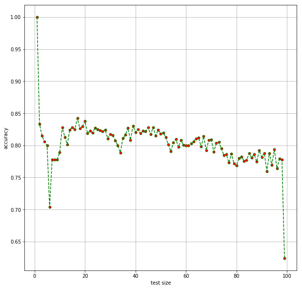

```python
# plot of accuracy for various values of test size
from sklearn.model_selection import train_test_split
from sklearn.preprocessing import StandardScaler
from sklearn import metrics as met
from sklearn.ensemble import RandomForestClassifier
acc=[]
for i in range(1,100,1):
    xtrain,xtest,ytrain,ytest=train_test_split(x,y,test_size=i/100,random_state=6)
    scaler=StandardScaler()
    xtrain=scaler.fit_transform(xtrain)
    xtest=scaler.transform(xtest)
    rf=RandomForestClassifier(n_estimators=50,n_jobs=10,random_state=6)
    rf.fit(xtrain,ytrain)
    ypred=rf.predict(xtest)
    accuracy=met.accuracy_score(ytest,ypred)
    acc.append(accuracy)
plt.figure(figsize=(10,10))
plt.plot(range(1,100,1),acc,color='g',linestyle='dashed',marker='.',markerfacecolor='r',markersize='10')
plt.xlabel('test size')
plt.ylabel('accuracy')
plt.grid(True)
print(acc.index(max(acc)),'-',max(acc))
```

#### from the above graph it is clear that accuracy can have maximum of 84% with the exception for test size of 1% for which accuracy reaches 100% since the number of samples get reduced.hence we cannot consider 1% test size for building the model

## Inference:

##### From the above classification models,KNN classifier gave highest accuracy on randomly selected samples for a given test split.

##### depending on the training which inturn depends on samples which are get selected the model may perform well or not and therefore model should be run for various test sizes and mean accuracy should be considered.